# LTOM.01.002 Data Analysis in Community Ecology

Carlos P. Carmona (carlos.perez.carmona@ut.ee)

Aurele Toussaint (aurele.toussaint@ut.ee)

Meelis Pärtel (meelis.partel@ut.ee)

Diego P. F. Trindade (diego.trindade@ut.ee)

Slendy Rodriguez-Alarcon (slendy.rodriguez@ut.ee)

Autumn 2023

# 8 Functional traits and phylogenetic analyses

Besides the number and abundance of taxa, a very important aspect of ecological communities includes the ecological differences between the organisms composing them. This variation can be expressed in terms of functional traits, which are measurable features of organisms that influence how they respond to and affect the environment and how they interact with other organisms. If we have two communities with five taxa each, but the taxa present in the first one have very different traits while those present in the second are very similar, we have higher functional diversity in the first community. In addition to traits, we can use phylogenetic information to assess how much phylogenetically related the present taxa are.

```r
load("community.rda")

traits <- read.table("vas.plant.traits.txt")
# seed weight mg, clonal spread classes, leaf size classes. NB! Many NA values!
head(traits)
```

```
##   seed.weight..g. clonal leaf
## 1            6.40      1   NA
## 2            2.36      1    5
## 3            4.00      2    4
## 4            3.16      2   NA
## 5              NA      1   NA
## 6            2.56      3    4
```

## 8.1 Weighted mean

The average trait value of a sample, weighted according to species’ abundances. It shows which trait value is the most common. If our traits have a very skewed distribution (which is generally the case with seed mass), it is recommendable to work with the logarithm, to avoid species with very high values being extremely influential (the mean is sensitive to outliers):

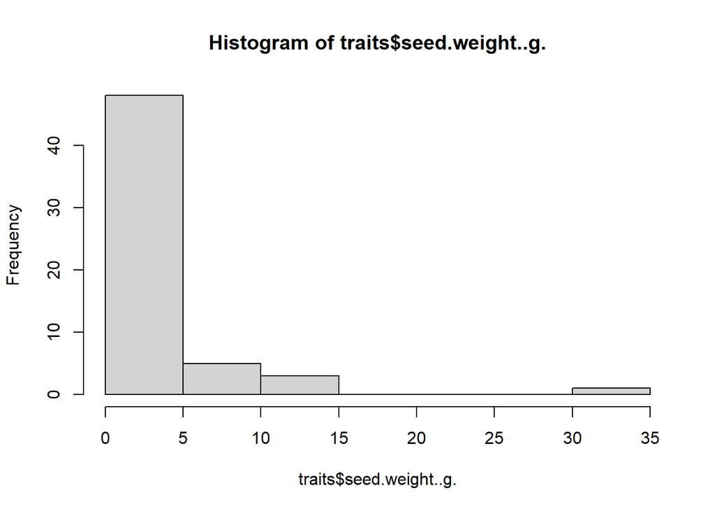

```r
hist(traits$seed.weight..g.) # very skewed
```

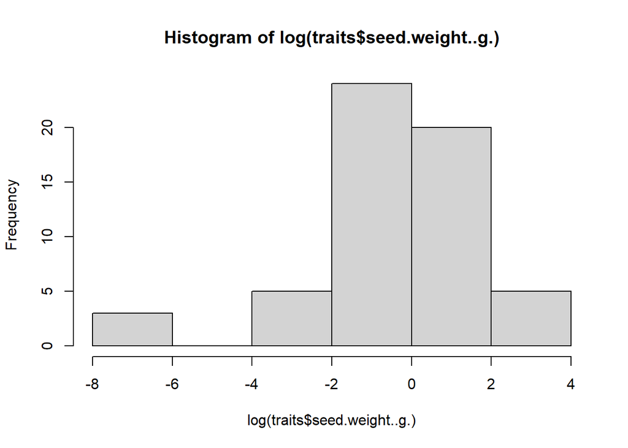

```r
hist(log(traits$seed.weight..g.)) # looks better
```

```r
traits$seed.weight..g.  <- log(traits$seed.weight..g.)

mean.seed <- numeric() # empty numeric object
for (i in 1:nrow(vas.plants)) {
  mean.seed[i] <- weighted.mean(traits$seed.weight..g.,
                                w = vas.plants[i, ],
                                na.rm = T)
}

mean.seed #In the log-scale
```

```
##  [1]  0.7587248981 -1.0523588258  0.0755782788 -0.3534966954 -0.4341183939
##  [6] -1.8067751943  1.3512422403  0.2903592473 -2.3447292993  0.2643987001
## [11]  0.4283597436 -0.0004662142  0.6720201664 -0.0751237178  0.7660636021
## [16]  0.2171485442  0.7208543721  0.3357505635 -0.1310540885  0.0600293211
## [21] -0.7430225683  0.0250576883 -0.5571641625 -0.9151129339 -0.0155489843
## [26] -0.0655949418  0.0077888053 -0.5051300122 -0.1111478318  0.6928334449
```

```r
exp(mean.seed) #In the original scale
```

```
##  [1] 2.13555144 0.34911328 1.07850765 0.70222831 0.64783555 0.16418274
##  [7] 3.86222036 1.33690768 0.09587315 1.30264746 1.53473809 0.99953389
## [13] 1.95818920 0.92762872 2.15128127 1.24252866 2.05618921 1.39899002
## [19] 0.87717033 1.06186768 0.47567398 1.02537427 0.57283122 0.40047140
## [25] 0.98457128 0.93651013 1.00781922 0.60342712 0.89480646 1.99937263
```

> calculate mean clonal spread and leaf size for sites.

**Answer**

```r
mean.clonal <- numeric() # empty numeric object
for (i in 1:nrow(vas.plants)) {
  mean.clonal[i] <- weighted.mean(traits[, 2], vas.plants[i, ], na.rm = T)
}
mean.clonal
```

```
##  [1] 1.742857 2.076923 1.581395 2.163636 2.705882 2.000000 1.812500 1.136364
##  [9] 2.800000 1.679245 1.571429 1.685714 1.800000 1.761905 2.000000 1.722222
## [17] 1.685714 1.695652 2.200000 1.543860 2.764706 1.693878 2.250000 2.500000
## [25] 1.833333 1.900000 2.250000 2.473684 2.333333 1.866667
```

```r
mean.leaf <- numeric()
for (i in 1:nrow(vas.plants)) {
  mean.leaf[i] <- weighted.mean(traits[, 3], vas.plants[i, ], na.rm = T)
}
mean.leaf
```

```
##  [1] 3.517241 2.923077 3.303030 3.545455 3.080000 3.523810 3.722222 3.705882
##  [9] 3.000000 3.333333 3.250000 3.333333 3.300000 3.108108 3.368421 3.562500
## [17] 3.470588 3.375000 3.000000 3.794118 3.000000 3.577778 3.000000 3.000000
## [25] 3.382353 3.222222 3.250000 3.166667 3.125000 3.400000
```

## 8.2 mean trait values for dark diversity

We can test the hypothesis that traits are linked to processes which limit species presences in communities. We can do this by comparing the mean trait values for observed and dark diversity using a paired t.test:

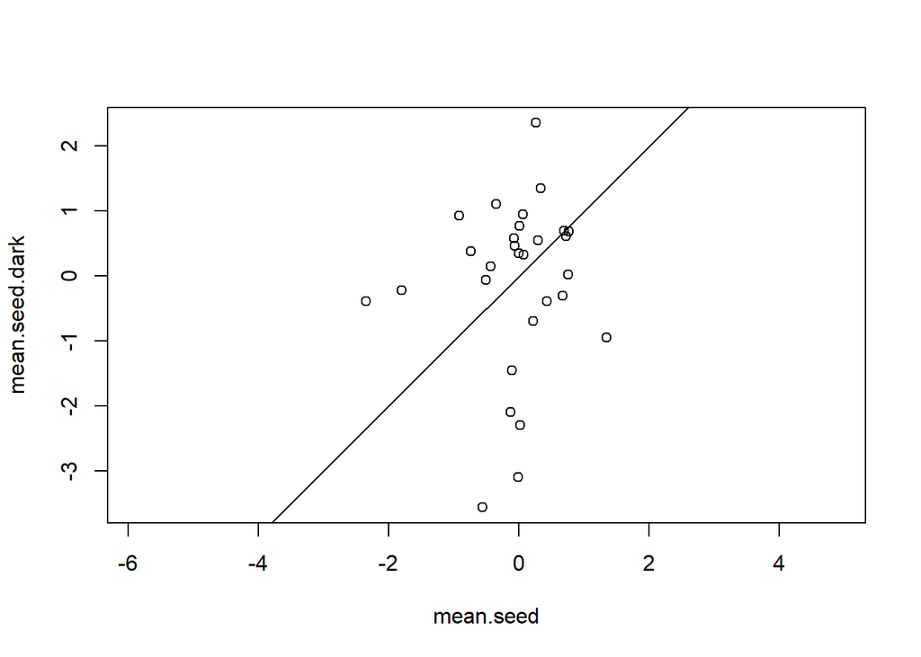

```r
## Using script for dark diversity from Topic 4
library(DarkDiv)
dark <- DarkDiv(vas.plants)$Dark > 0.7 # Defining dark
dark[is.na(dark)] <- 0 # Replacing NA with zeros


mean.seed.dark <- numeric()
for (i in 1:nrow(dark)) {
  mean.seed.dark[i] <-  weighted.mean(traits$seed.weight..g., dark[i, ], na.rm = T)
}

plot(mean.seed, mean.seed.dark, asp = T)
abline(0, 1)
```

```r
# Hypothesis: large seeds establish more easily in community (more resources),
# so that we expect to find in average larger seed in observed community compared
# to dark diversity

t.test(mean.seed - mean.seed.dark, alternative = "greater") # one sided question!
```

```
##
##  One Sample t-test
##
## data:  mean.seed - mean.seed.dark
## t = 0.24958, df = 28, p-value = 0.4024
## alternative hypothesis: true mean is greater than 0
## 95 percent confidence interval:
##  -0.3919486        Inf
## sample estimates:
##  mean of x
## 0.06739051
```

```r
# t-test assumption: normal distribution:
shapiro.test(mean.seed - mean.seed.dark) #OK
```

```
##
##  Shapiro-Wilk normality test
##
## data:  mean.seed - mean.seed.dark
## W = 0.94414, p-value = 0.1287
```

```r
## Non-parametric alternative is wilcox.test()
```

## 8.3 Functional space of taxa

Besides mean values, we can also look at how large is the functional space covered by a taxa within a site. Size of the functional space describes functional diversity. NB! Related to species richness!

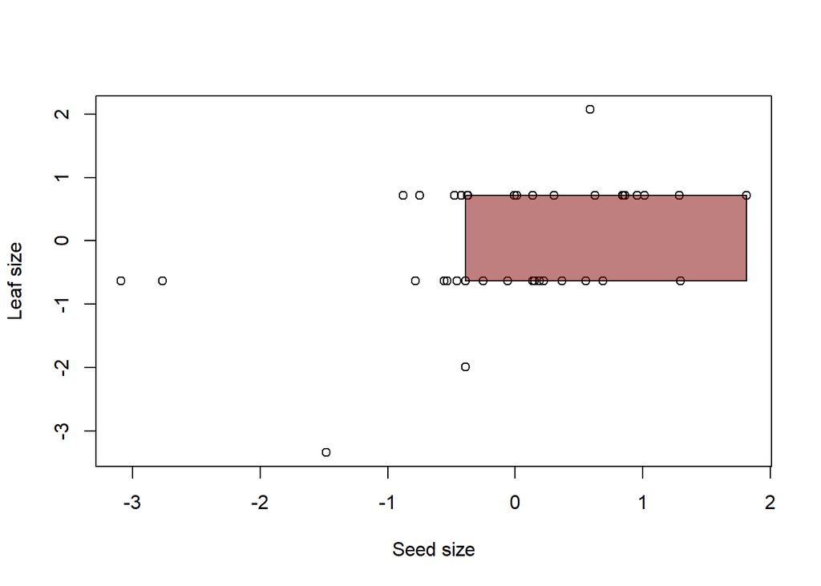

```r
traits.scale <- scale(traits)  # scaling traits

row.names(traits.scale) <- names(vas.plants) # putting names of taxa

traits.scale <- traits.scale[complete.cases(traits), ] # omitting taxa with NA
vas.plants.traits <- vas.plants[, complete.cases(traits)] # same with community data


plot(traits.scale[, 1], traits.scale[, 3], xlab = "Seed size",
     ylab = "Leaf size")
i <- 1 # id for sample
site1 <- data.frame(x = traits.scale[vas.plants.traits[i, ] > 0, 1],
                    y = traits.scale[vas.plants.traits[i, ] > 0, 3])
rect(min(site1$x),
     min(site1$y),
     max(site1$x),
     max(site1$y),
     col = rgb(0.5, 0, 0, 0.5))
```

> Show the range rectangle for sites 2 and 3. Which one has the largest functional diversity?

**Answer**

```r
i=2 # id for sample
site1=data.frame(x=traits.scale[vas.plants.traits[i,]>0,1],
                 y=traits.scale[vas.plants.traits[i,]>0,3])
rect(min(site1$x),min(site1$y),max(site1$x),max(site1$y),col=rgb(0,0.5,0,0.5)) # changed rgb parameters (red, green, blue, transparency)
```

[output not shown]

```r
# smaller

i=3 # id for sample
site1=data.frame(x=traits.scale[vas.plants.traits[i,]>0,1],
                 y=traits.scale[vas.plants.traits[i,]>0,3])
rect(min(site1$x),min(site1$y),max(site1$x),max(site1$y),col=rgb(0,0,0.5,0.5))
```

[output not shown]

```r
# larger
```

We can find seed size range for all sites using the `apply` function.

```r
seed.range <- apply(vas.plants.traits, 1,
                    function(x){max(traits.scale[x > 0, 1]) -
                      min(traits.scale[x > 0, 1])})
seed.range
```

```
##   X001Vapramae       X002Illi   X003Vitipalu    X004Konguta    X005Vehendi
##      2.2006137      3.2824281      3.2916288      2.1730898      2.7548619
##    X006.Erumae   X007Porgumae     X008Aardla   X009Kurepalu  X010Sarakuste
##      2.7181131      1.6690650      1.5723804      2.7025766      2.0717218
##      X011Kannu      X012Vonnu     X013Rookse    X014Kammeri     X015Kambja
##      1.7524058      2.0457201      1.7172918      4.0587498      1.6690650
##      X016Reola     X017Ignase    X018Unikula X019Haavametsa X020Kruusahaua
##      2.0457201      1.6846015      1.6846015      0.5798515      1.5666966
##      X021Aravu  X026Pedajamae       X027Miti    X028Puhaste  X031Pimmelaan
##      0.3284283      4.9031903      0.5798515      4.0587498      4.3871781
##     X032Logina  X033Voorepalu X036Taevaskoja    X044Savimae X073Pausakunnu
##      1.6846015      1.6846015      1.2355453      1.6846015      1.7172918
```

> Calculate leaf size range for all sites. Find if these two ranges (seed weight and leaf size) are related to species richness.

**Answer**

```r
leaf.range=apply(vas.plants.traits,1,function(x) max(traits.scale[x>0,2])-min(traits.scale[x>0,2]))

shapiro.test(rowSums(vas.plants>0)) # Ok
```

```
##
##  Shapiro-Wilk normality test
##
## data:  rowSums(vas.plants > 0)
## W = 0.97798, p-value = 0.7696
```

```r
shapiro.test(seed.range) # Not OK
```

```
##
##  Shapiro-Wilk normality test
##
## data:  seed.range
## W = 0.90508, p-value = 0.0112
```

```r
cor.test(rowSums(vas.plants>0),seed.range, method="spearman")
shapiro.test(leaf.range) # not ok
```

[output not shown]

```
##
##  Shapiro-Wilk normality test
##
## data:  leaf.range
## W = 0.27344, p-value = 4.243e-11
```

```r
cor.test(rowSums(vas.plants>0),leaf.range,method="spearman")
```

[output not shown]

## 8.4 Functional diversity based on mean pairwise distance

Now we will calculate the average functional distance between all taxa within a sample. This is a functional diversity measure which is NOT necessarily related to species richness (which is a good thing in general, because if functional diversity is trivially related to species richness, it does not convey much new information). We use the function `melodic` from this paper:

de Bello, F., Carmona, C.P., Lepš, J., Szava-Kovats, R. & Pärtel, M. 2016. Functional diversity through the mean trait dissimilarity: resolving shortcomings with existing paradigms and algorithms. Oecologia 180: 933-940. https://link.springer.com/article/10.1007%2Fs00442-016-3546-0

Supp. material 3 includes the function melodic: https://static-content.springer.com/esm/art%3A10.1007%2Fs00442-016-3546-0/MediaObjects/442_2016_3546_MOESM3_ESM.r

Just read the function:

```r
##MEan DIssimilarity Components##
#samp:  community matrix; sites in lines, species in columns
#dis:   dissimilarity matrix
#type:  "both" for results with abundances weighted and non-weighted
#       "abundance" for results with abundances weighted
#       "presence" for results with abundances non-weighted

melodic <- function(samp,dis,type="both"){
    samp <- as.matrix(samp)
  dis <- as.matrix(dis)
  if(is.null(colnames(samp)) | is.null(colnames(dis)) ){
    stop("Both samp and dis must have colnames.\n")
  }
  N<-dim(samp)[1]
    melodic<-list()
    if (type=="both"){
        melodic$abundance<-list()
        melodic$abundance$mpd<-melodic$abundance$rao<-melodic$abundance$simpson<-numeric(N)
        melodic$presence<-list()
        melodic$presence$mpd<-melodic$presence$rao<-melodic$presence$simpson<-numeric(N)
    }
    if (type=="abundance"){
        melodic$abundance<-list()
        melodic$abundance$mpd<-melodic$abundance$rao<-melodic$abundance$simpson<-numeric(N)
    }
    if (type=="presence"){
        melodic$presence<-list()
        melodic$presence$mpd<-melodic$presence$rao<-melodic$presence$simpson<-numeric(N)
    }
    for (i in 1:N){
        sppInSample<-names(samp[i,samp[i, ]>0])
        melodic$richness[i]<-rowSums(samp>0)[i]
        if (length(sppInSample)>1){
            sample.dis<-dis[sppInSample,sppInSample]
            abund.w<-numeric(length(sppInSample))
            if (type=="both" | type=="abundance"){
                abund.w <- samp[i , sppInSample] / sum(samp[i , sppInSample])
                sample.weights <- outer(abund.w , abund.w)
                melodic$abundance$mpd[i] <- weighted.mean(sample.dis[lower.tri(sample.dis)] , sample.weights[lower.tri(sample.weights)])
                melodic$abundance$rao[i] <- sum(sample.weights * sample.dis)
                melodic$abundance$simpson[i] <- sum(2*sample.weights[lower.tri(sample.weights)])
            }
            if (type=="both" | type=="presence"){
                abund.nw <- rep(1 , length(sppInSample)) / length(sppInSample)
                sample.weights <- outer(abund.nw , abund.nw)
                melodic$presence$mpd[i] <- weighted.mean(sample.dis[lower.tri(sample.dis)] , sample.weights[lower.tri(sample.weights)])
                melodic$presence$rao[i] <- sum(sample.weights * sample.dis)
                melodic$presence$simpson[i] <- sum(2*sample.weights[lower.tri(sample.weights)])
            }
        }   else {
            if (type=="both" | type=="abundance"){
                melodic$abundance$mpd[i] <- NA
                melodic$abundance$rao[i] <- melodic$abundance$simpson[i] <-0
            }
            if (type=="both" | type=="presence"){
                melodic$presence$mpd[i] <- NA
                melodic$presence$rao[i] <- melodic$presence$simpson[i] <-0
            }
        }
    }
    out<-melodic
    return(out)
}

############
```